# Conceptos básicos de imágenes

### 12.9 Ejercicio 9: análisis de intensidades

Observá los valores de los canales y contestá: ¿cuál es el canal dominante en una zona determinada?

```python
# Elegimos un píxel central
x, y = img.shape[1] // 2, img.shape[0] // 2
b_val, g_val, r_val = img[y, x]
print(f"Píxel central ({x},{y}) -> B={b_val}, G={g_val}, R={r_val}")
```

```
Píxel central (536,335) -> B=26, G=79, R=152
```

### 12.10 Ejercicio 10: canal promedio

Promediá los tres canales para obtener una representación aproximada de intensidad.

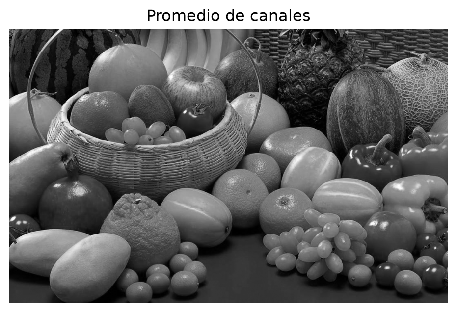

```python
img_promedio = np.mean(img, axis=2).astype(np.uint8)

plt.figure(figsize=(6,6))
plt.imshow(img_promedio, cmap="gray")
plt.title("Promedio de canales")
plt.axis("off")
plt.show()
```

### 12.11 Ejercicio 11: desafío final

Escribí un bloque de código que:

1. cargue la imagen,
2. la convierta a grises,
3. extraiga el canal rojo,
4. muestre los tres resultados en una figura con 3 subplots.

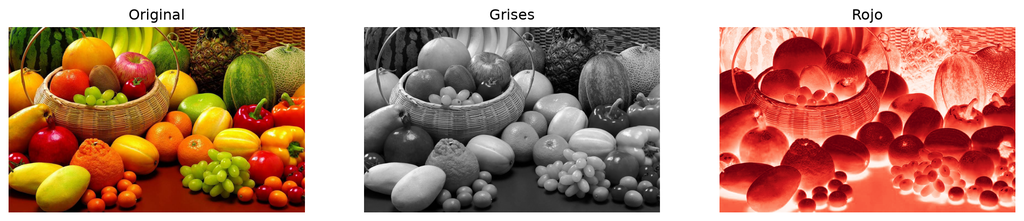

```python
# Desafío: completa este bloque
img_rgb = cv2.cvtColor(img, cv2.COLOR_BGR2RGB)
img_gray = cv2.cvtColor(img, cv2.COLOR_BGR2GRAY)
img_red = img[:, :, 2]

fig, axes = plt.subplots(1, 3, figsize=(15, 5))

axes[0].imshow(img_rgb)
axes[0].set_title("Original")
axes[0].axis("off")

axes[1].imshow(img_gray, cmap="gray")
axes[1].set_title("Grises")
axes[1].axis("off")

axes[2].imshow(img_red, cmap="Reds")
axes[2].set_title("Rojo")
axes[2].axis("off")

plt.show()
```

## 13 Conclusión

Las imágenes digitales son matrices numéricas. Cada píxel tiene información que puede representarse como intensidad o como una combinación de canales. Entender esta base es clave para comenzar a trabajar con filtros, transformaciones, segmentación y análisis de imágenes.

En la siguiente sesión veremos operaciones básicas como recorte, cambio de tamaño y rotación.